# ABDS User Maunal

Dongping Du

2024-02-15

We developed the ABDS tool suite specifically for analyzing biologically diverse samples. Mechanism-integrated group-wise pre-imputation is designed to recruit signature genes that represent informative missingness, a cosine-based one-sample test is extended to detect downregulated signature genes, and a unified heatmap is designed to display multiple phenotypic groups. We discuss the methodological principles and demonstrate the effectiveness of three analytics tools, supported by comparative evaluations and biomedical showcases.

## Quick Start

You can install the latest version of ABDS from GitHub by

```r
devtools::install_github("niccolodpdu/ABDS")
```

## MGpI: Mechanism-integrated group-wise pre-imputation

Missing values associated with these genes are expected to have a group-specific mix of different missing mechanisms and cross-group uneven missing rates. Thus, using an overall missing rate for data quality control would be problematic and could adversely affect subsequent analyses. We propose a mechanism-integrated group-wise pre-imputation (MGpI) strategy that explicitly considers mixed missing mechanisms across different phenotypic groups.

In the following example, we will see how to apply MGpI to real-world gene expression data (GSE19380) with artificially introduced missing values from a mixed mechanisms of missingness - lower limit of detection (LLOD) and missing at random (MAR). Please note that MGpI requires the group information of samples. In this case, we selected 16 samples from GSE19380 that are pure samples of four primary brain cell cultures according to the phenotypic data in the GSE profile (4 samples in each group: Primary neuronal culture, Primary astrocytic culture, Primary oligodendrocytic culture, Primary microglial culture), and pre-loaded them in our package.

```r
## Read-in
library(ABDS)
readin<-ABDS::sample_data_MGpI

## MGpI Imputation
nRep=c(4,4,4,4) # Group-info vector: four samples in each one of the four groups
MGpI_imputed<-ABDS::MGpI(readin,nRep = nRep)
```

## eCOT: Extended Cosine-based One-sample Test

In addition to signature genes, a molecularly distinct group may also be characterized by features that are uniquely silent in the group of interest but in no others – so-called downregulated signature genes (DSGs).

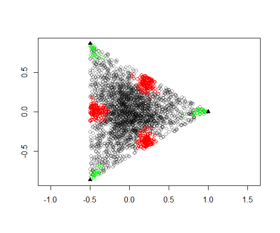

```r
## Read-in
library(ABDS)
readin<-ABDS::sample_data_eCOT

## Plot the ground truth DSG distribution
num_dsg = 450
num_sg = 60
ABDS::scatter_plot(readin,mg.info = TRUE, mg = c(list(1:num_dsg),list((num_dsg+1):(num_sg+num_dsg))), mg.col = c('red','green')) # Red dots are DSGs
```

Now let’s take a look at the DSGs identified by eCOT:

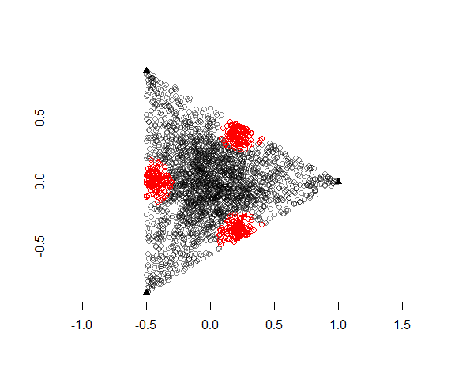

```r
## Read-in
predict_ecot<-1-as.numeric(ABDS::eCOT(readin)[,1])
ABDS::scatter_plot(readin,mg.info = TRUE, mg = list(which(predict_ecot<sort(predict_ecot)[num_dsg])), mg.col = c('red'))
```

It’s also possible to use the ROC curve to help evaluate the outcome of eCOT:

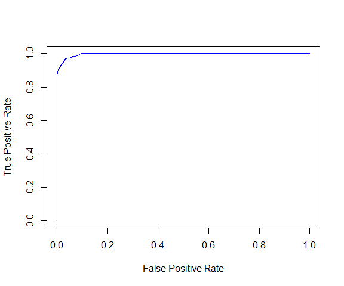

```r
## ROC
library(pROC)
predict_ecot<-predict_ecot/max(predict_ecot)
gt<-c(rep(0,num_dsg),rep(1,(dim(readin)[1]-num_dsg))) # Assigning ground truth labels
roc_curve_ecot <- roc(gt, predict_ecot)
plot((1-roc_curve_ecot$specificities), roc_curve_ecot$sensitivities,
     type = "l", xlab = "False Positive Rate", ylab = "True Positive Rate", col = "blue",lwd = 1.5)
```

## uniHM: Unified heatmap design for comparative display

```r
## Read-in
library(ABDS)
library(heatmaply)
readin<-ABDS::sample_data_uniHM

## Input modification
data_plot<-ABDS::heatmap_data_modification(readin)

## Generating plot
thld <- 2.5
data_plot[data_plot > thld] <- thld
data_plot[data_plot < -thld] <- -thld
color <- ABDS::redblue(300)

heatmaply((data_plot),colors = rgb(color), cluster = FALSE, dendrogram = c("none") )
```

[interactive chart not shown]